# Further MOFA-COSMOS downstream analyses

Pascal Lafrenz

2023-02-16

In order to evaluate the data obtained from the MOFA-COSMOS pipeline downstream, further analyses can be performed.

```r
library(decoupleR)
library(liana)
library(moon)
library(readr)
library(pheatmap)
library(dplyr)
library(reshape2)
library(MOFA2)
library(ggplot2)
library(RCy3)
library(RColorBrewer)
library(cosmosR)
```

## Calculate cell-line specific transcriptomics

Firstly, we can calculate cell-line specific transcriptomic values by multiplying the MOFA factor weight (here: Factor 4) with the ‘raw’ transcriptomic values.

```r
# RNA cell-line-specific values (RNA_specific = MOFA_factor_weight * RNA_raw)

## Get RNA raw values
RNA_raw <- as.data.frame(read_csv("data/RNA/RNA_log2_FPKM_clean.csv"))
rownames(RNA_raw) <- RNA_raw[,1]
RNA_raw <- RNA_raw[,-1]
RNA_raw <- melt(as.data.frame(cbind(RNA_raw,row.names(RNA_raw))))
RNA_raw$view <- "RNA"
RNA_raw <- RNA_raw[,c(2,1,4,3)]
names(RNA_raw) <- c("sample","feature","view","value")

## Get MOFA factor weights from Factor 4
model <- load_model('results/mofa/mofa_res_10factor.hdf5')
meta_data <- read_csv("data/metadata/RNA_metadata_cluster.csv")[,c(1,2)]
colnames(meta_data) <- c("sample","cluster")
samples_metadata(model) <- meta_data[meta_data$sample %in% samples_metadata(model)$sample,]

weights <- get_weights(model, views = "all", factors = "all")
RNA_MOFA <- data.frame(weights$RNA[,4])
RNA_MOFA <- cbind(rownames(RNA_MOFA), RNA_MOFA)
colnames(RNA_MOFA) <- c("feature", "value")
RNA_MOFA$feature <- gsub("_RNA","",RNA_MOFA$feature)

## Calculate score
RNA_weight_cell_line <- merge(RNA_raw, RNA_MOFA, by.x='feature', by.y='feature')
RNA_weight_cell_line <- cbind(RNA_weight_cell_line, "final" = (RNA_weight_cell_line$value.x*RNA_weight_cell_line$value.y))
colnames(RNA_weight_cell_line) <- c("feature","sample","view","RNA_raw","RNA_MOFA","Final")

nodes_cellline_weight <- dcast(RNA_weight_cell_line, feature~sample, value.var = "Final")
rownames(nodes_cellline_weight) <- nodes_cellline_weight$feature
nodes_cellline_weight <- nodes_cellline_weight[,-1]
```

Then we can further select only nodes from the MAPK signaling pathway.

```r
## Select nodes from subnetwork EGF_EGFR_RAS_ERK_pathway

interesting_nodes <- data.frame("name" = c("CCNA2","EGFR", "FOS", "HRAS",  "JUN", "MAP2K1", "MAP2K2", "MAPK1", "MAPK3", "MYC",  "NFKB1", "PCNA", "RAF1", "STAT3", "TGFB1", "THBS1", "VEGFA"))
nodes_cellline_weight_filtered <- nodes_cellline_weight[rownames(nodes_cellline_weight) %in% interesting_nodes$name,]
```

And add the meta data information.

```r
RNA_metadata_cluster <- as.data.frame(read_csv(file = "data/metadata/RNA_metadata_cluster.csv"))
```

```r
tissue_origin_cluster <- as.data.frame(RNA_metadata_cluster[,c(2,3)]) #:2,8
colnames(tissue_origin_cluster) <- c("cluster","Tissue") #", , "histology")
rownames(tissue_origin_cluster) <- RNA_metadata_cluster[,1]
tissue_origin_cluster$Tissue <- as.character(tissue_origin_cluster$Tissue)
tissue_origin_cluster$cluster <- as.character(tissue_origin_cluster$cluster)
```

To visualize the results, heatmaps are shown.

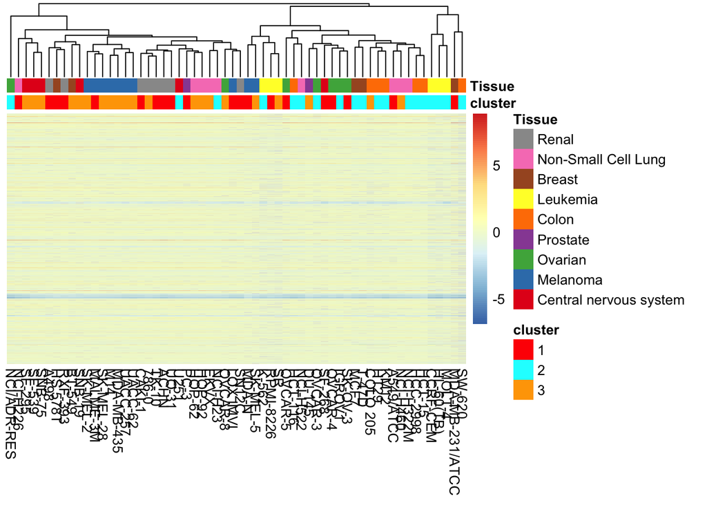

```r
var1 <- rev(brewer.pal(9, "Set1"))
names(var1) <- unique(tissue_origin_cluster$Tissue)
var2 <- c("red","cyan","orange")
names(var2) <- unique(tissue_origin_cluster$cluster)[order(unique(tissue_origin_cluster$cluster))]
anno_colors <- list(Tissue=var1,
                    cluster=var2)

pheatmap(nodes_cellline_weight,
         display_numbers = F,
         cluster_rows = F,
         show_rownames =  F,
         annotation_col = tissue_origin_cluster,
         annotation_colors =  anno_colors)
```

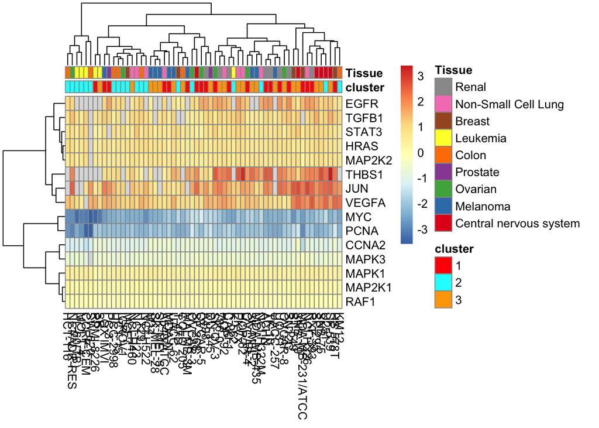

```r
pheatmap(nodes_cellline_weight_filtered,
         display_numbers = F,
         annotation_col = tissue_origin_cluster,
         annotation_colors =  anno_colors)
```

Since, we are also interested in comparing the two cell lines with the most differing features, we use the MOFA factor values to determine these by calculating the highest difference.

```r
# Calculate activity scores of most different cell lines

## Get cell line factor weights
factor_weights <- as.data.frame(get_factors(model,factors = 4))
factor_weights$sample <- rownames(factor_weights)
factor_weights <- merge(factor_weights,meta_data,by="sample")

## Identify cell lines with highest difference in factor values
diff_matrix <- data.frame()
for(x in c(1:58)) {
  for(y in c(1:58)) {
    diff_matrix[x,y] <- abs(factor_weights$Factor4[x]-factor_weights$Factor4[y])
  }
}
rownames(diff_matrix) <- factor_weights$sample
colnames(diff_matrix) <- factor_weights$sample

max(diff_matrix) #sample 28 and 44 = MOLT-4 & SF-539
```

```
## [1] 3.563723
```

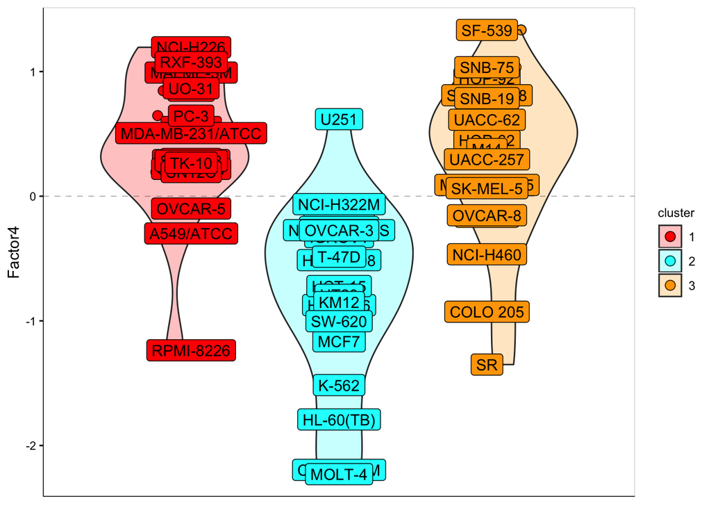

```r
max_cell_lines <- rownames(diff_matrix)[which(diff_matrix == max(diff_matrix), arr.ind = T)][c(1,2)]

plot_factor(model,
            factors = 4,
            color_by = "cluster",
            dot_size = 3,
            dodge = T,
            legend = T,
            add_violin = T,
            violin_alpha = 0.25) +
  scale_color_manual(values=c("1"="red", "2"="cyan", "3"="orange")) +
  scale_fill_manual(values=c("1"="red", "2"="cyan", "3"="orange")) +
  geom_label(label=model@samples_metadata$sample, show.legend = F, position=position_dodge(width=0.9))
```

Let’s focus on the MAPK signaling pathway values for these cell lines.

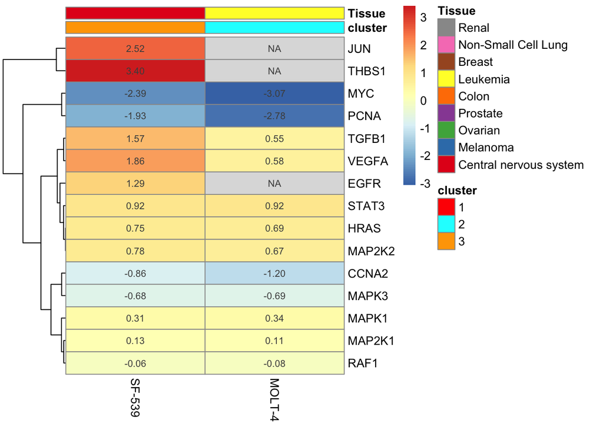

```r
pheatmap(nodes_cellline_weight_filtered[,max_cell_lines],
         display_numbers = T,
         annotation_col = tissue_origin_cluster,
         annotation_colors =  anno_colors,
         cluster_cols = F)
```

## Use cell-line specific transcriptomics to infer biological activities

Further, we can use the cell-line specific transcriptomic values to calculate cell-line specific activity scores with decoupleR and prior knowledge.

```r
## Calculate cell-line specific activity scores
### LIANA, mOOn, Dorothea

# Load LIANA (receptor and ligand) consensus network
ligrec_ressource <- distinct(liana::decomplexify(liana::select_resource("Consensus")[[1]]))
ligrec_geneset <- ligrec_ressource[,c("source_genesymbol","target_genesymbol")]
ligrec_geneset$set <- paste(ligrec_geneset$source_genesymbol, ligrec_geneset$target_genesymbol, sep = "___")
ligrec_geneset <- reshape2::melt(ligrec_geneset, id.vars = "set")[,c(3,1)]
names(ligrec_geneset)[1] <- "gene"
ligrec_geneset$mor <- 1
ligrec_geneset$likelihood <- 1
ligrec_geneset <- distinct(ligrec_geneset)

# Load Dorothea (TF) network
dorothea_df <- decoupleR::get_dorothea()

# Load meta footprint analysis (moon) regulatory network
moon_regulons <- moon::build_moon_regulons()


lig_rec_scores <- list()
moon_scores <- list()
dorothea_scores <- list()

for(i in unique(RNA_weight_cell_line$sample)) {
  RNA_sample <- RNA_weight_cell_line[RNA_weight_cell_line$sample == i,6]
  names(RNA_sample) <- RNA_weight_cell_line[RNA_weight_cell_line$sample == i,1]
  RNA_sample <- RNA_sample[!is.na(RNA_sample)]

  # Calculate regulatory activities from Receptor and Ligand network
  ligrec_high_vs_low <- run_wmean(mat = as.matrix(RNA_sample), network = ligrec_geneset, times = 1000, .source = set, .target = gene, minsize = 2, seed = 42)
  ligrec_high_vs_low <- ligrec_high_vs_low[ligrec_high_vs_low$statistic == "norm_wmean",]
  ligrec_high_vs_low_vector <- ligrec_high_vs_low$score
  names(ligrec_high_vs_low_vector) <- ligrec_high_vs_low$source

  rec_inputs <- ligrec_high_vs_low_vector
  names(rec_inputs) <- gsub(".+___","",names(rec_inputs))
  rec_inputs <- tapply(rec_inputs, names(rec_inputs), mean)
  receptors <- names(rec_inputs)
  rec_inputs <- as.numeric(rec_inputs)
  names(rec_inputs) <- receptors

  lig_rec_scores[[i]] <- rec_inputs

  lig_inputs <- ligrec_high_vs_low_vector
  names(lig_inputs) <- gsub("___.+","",names(lig_inputs))
  lig_inputs <- tapply(lig_inputs, names(lig_inputs), mean)
  ligands <- names(lig_inputs)
  lig_inputs <- as.numeric(lig_inputs)
  names(lig_inputs) <- ligands

  lig_rec_scores[[i]] <- c(lig_rec_scores[[i]],lig_inputs)

  # Calculate regulatory activities from TF network
  TF_high_vs_low <- run_wmean(mat = as.matrix(RNA_sample), network = dorothea_df, times = 1000, minsize = 10, seed = 42)
  TF_high_vs_low <- TF_high_vs_low[TF_high_vs_low$statistic == "norm_wmean",]
  TF_high_vs_low_vector <- TF_high_vs_low$score
  names(TF_high_vs_low_vector) <- TF_high_vs_low$source

  dorothea_scores[[i]] <- TF_high_vs_low_vector

  # Prepare moon analysis input
  TF_high_vs_low <- as.data.frame(TF_high_vs_low[,c(2,4)])
  row.names(TF_high_vs_low) <- TF_high_vs_low[,1]

  # Calculate TF regulatory activities from moon network
  moon_high_vs_low <- run_wmean(mat = as.matrix(TF_high_vs_low[,-1,drop = F]), network = moon_regulons, times = 1000, minsize = 10, seed = 42)
  moon_high_vs_low <- moon_high_vs_low[moon_high_vs_low$statistic == "norm_wmean",]
  moon_high_vs_low_vector <- moon_high_vs_low$score
  names(moon_high_vs_low_vector) <- moon_high_vs_low$source
  moon_high_vs_low_vector <- moon_high_vs_low_vector[!(names(moon_high_vs_low_vector) %in% names(TF_high_vs_low_vector))] #exclude all found in TF activity estimation, only keep others to prevent overrepresentation

  moon_scores[[i]] <- moon_high_vs_low_vector
}
```

After that, we create a dataframe that includes the activity values for our nodes inside the MAPK signaling pathway.

```r
## Filter interesting nodes
lig_rec_scores_df <- data.frame(t(data.table::rbindlist(
  lapply(lig_rec_scores, function(x) data.table::data.table(t(x))),
  fill = TRUE)))
colnames(lig_rec_scores_df) <- names(lig_rec_scores)
lig_rec_scores_filtered_df <- lig_rec_scores_df[rownames(lig_rec_scores_df) %in% interesting_nodes$name,]

dorothea_scores_df <- data.frame(t(data.table::rbindlist(
  lapply(dorothea_scores, function(x) data.table::data.table(t(x))),
  fill = TRUE)))
colnames(dorothea_scores_df) <- names(dorothea_scores)
dorothea_scores_filtered_df <- dorothea_scores_df[rownames(dorothea_scores_df) %in% interesting_nodes$name,]

moon_scores_df <- data.frame(t(data.table::rbindlist(
  lapply(moon_scores, function(x) data.table::data.table(t(x))),
  fill = TRUE)))
colnames(moon_scores_df) <- names(moon_scores)
moon_scores_filtered_df <- moon_scores_df[rownames(moon_scores_df) %in% interesting_nodes$name,]

## Create dataframe with activity scores
activity_scores <- rbind(lig_rec_scores_filtered_df,dorothea_scores_filtered_df[!(rownames(dorothea_scores_filtered_df) %in% c(rownames(moon_scores_filtered_df), rownames(lig_rec_scores_filtered_df)))], moon_scores_filtered_df[!(rownames(moon_scores_filtered_df) %in% c(rownames(dorothea_scores_filtered_df), rownames(lig_rec_scores_filtered_df))),])

activity_scores[,1] <- rownames(activity_scores)
write_csv(activity_scores, file = "data/mofa/activity_scores.csv")
```

We can visualize the different activity scores with heatmaps.

```r
## Visualize results
activity_scores <- as.data.frame(read_csv(file = "data/mofa/activity_scores.csv"))
```

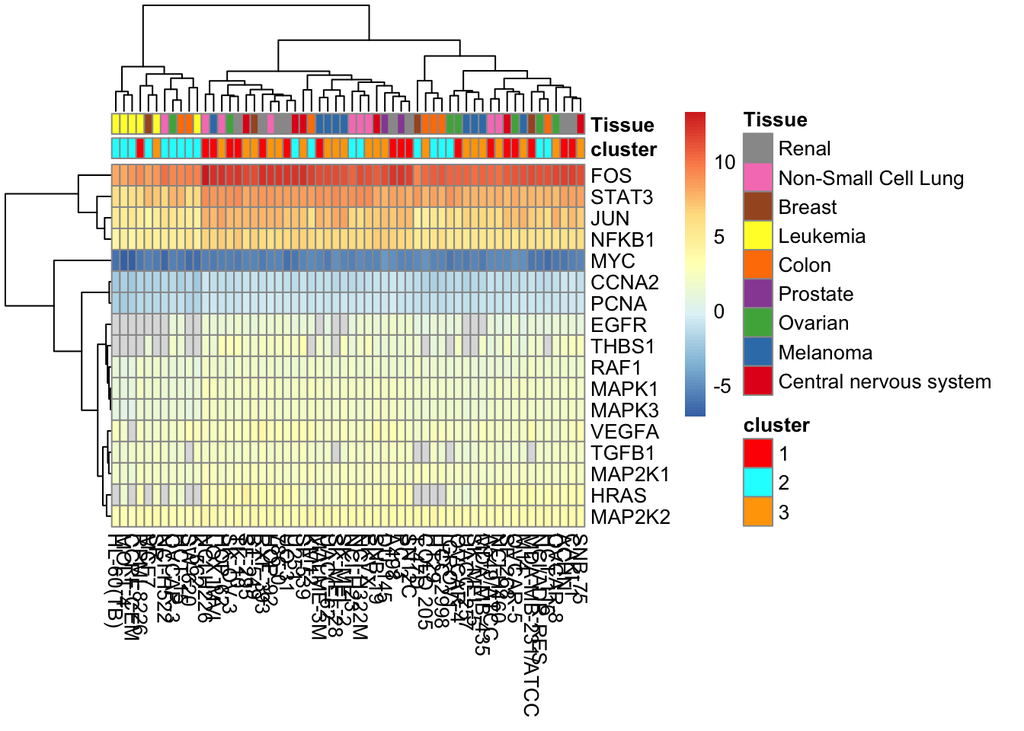

```r
rownames(activity_scores) <- activity_scores[,1]
activity_scores <- activity_scores[,-1]

pheatmap(activity_scores[,-1],
         display_numbers = F,
         cluster_rows = T,
         cluster_cols = T,
         annotation_col = tissue_origin_cluster,
         annotation_colors =  anno_colors)
```

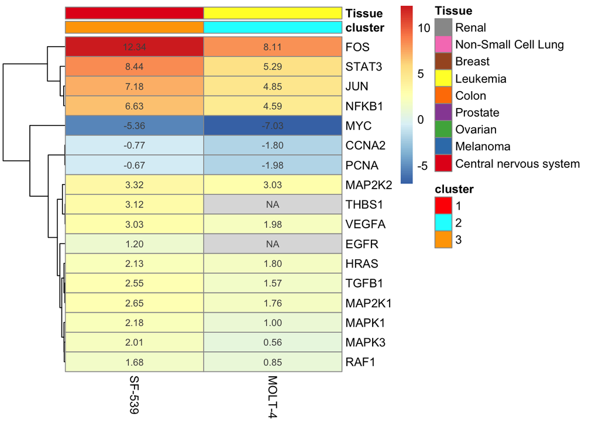

```r
pheatmap(activity_scores[,colnames(activity_scores) %in% max_cell_lines],
         display_numbers = T,
         cluster_rows = T, cluster_cols = F,
         annotation_col = tissue_origin_cluster,
         annotation_colors =  anno_colors)
```

Since we would like to see relative differences between our cell lines, we calculate the relative activity values here through scaling ($\frac{feature_{single} - mean(feature)}{sd(feature)}$).

```r
## Transform activity values to relative ones
SDs <- apply(activity_scores,1,function(x){sd(x,na.rm = T)})
means <- rowMeans(activity_scores, na.rm = T)
activity_scores_scaled <- (activity_scores - means) / SDs
```

Let’s visualize the scaled activity scores.

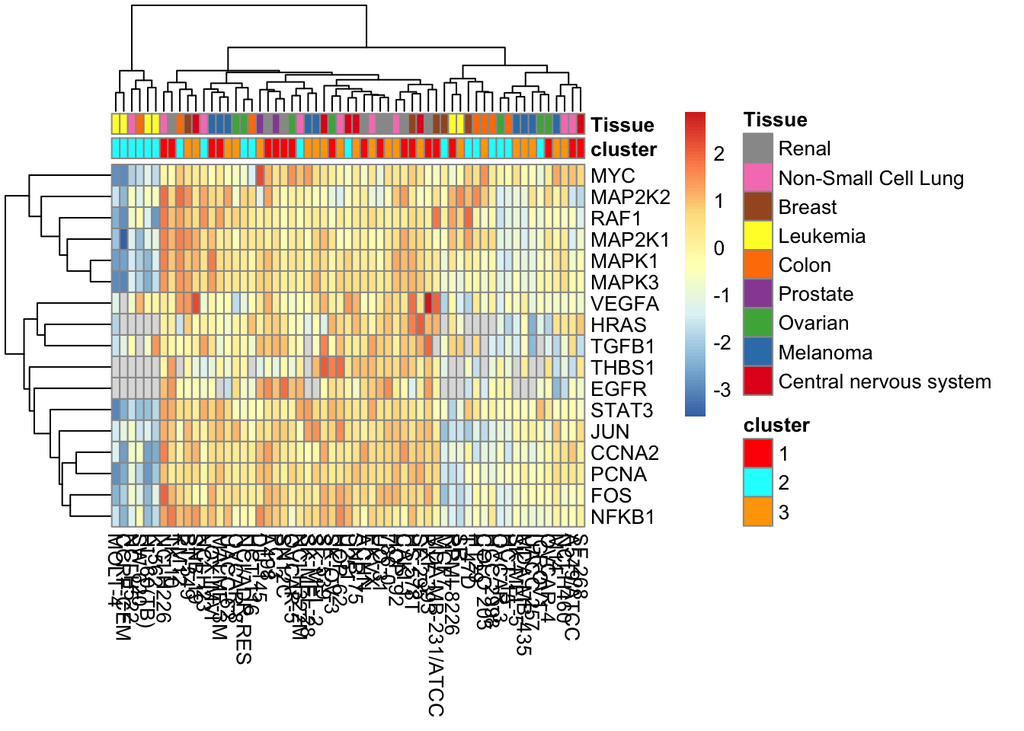

```r
## Visualize results
pheatmap(activity_scores_scaled,
         display_numbers = F,
         cluster_rows = T,
         cluster_cols = T,
         annotation_col = tissue_origin_cluster,
         annotation_colors =  anno_colors)
```

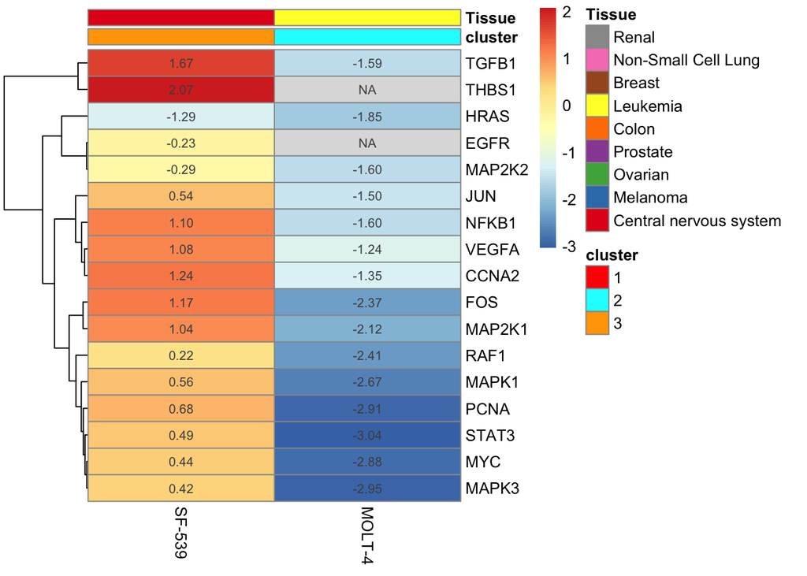

```r
pheatmap(activity_scores_scaled[,colnames(activity_scores_scaled) %in% max_cell_lines],
         display_numbers = T,
         cluster_rows = T,
         cluster_cols = F,
         annotation_col = tissue_origin_cluster,
         annotation_colors =  anno_colors)
```

## Visualize results of cell-line specific values with CytoScape

Finally, we can add the activity scores to our network in CytoScape allowing us to visualize all results nicely.

```r
## Add weighted, transformed activity scores to network
combined_SIF_reduced <- read_csv(file = "results/cosmos/SIF_mofamoon_combined_reduced.csv")
combined_ATT_reduced <- read_csv(file = "results/cosmos/ATT_mofamoon_combined_reduced.csv")

activity_scores_scaled <- cbind("id"=rownames(activity_scores_scaled),activity_scores_scaled)

style.name <- "dataStyle_activity"
createVisualStyle(style.name)

activity_weights <- data.frame()
cosmos_weights <- data.frame()

for(i in max_cell_lines) {

  nodes <- data.frame(id = combined_ATT_reduced$Nodes,
                      NodeType = as.integer(combined_ATT_reduced$NodeType),
                      mofa_weights = as.numeric(combined_ATT_reduced$mofa_weights),
                      Activity = combined_ATT_reduced$Activity,
                      stringsAsFactors = F)

  nodes <- merge(nodes, activity_scores_scaled[,c("id",i)], by = "id", all = T)

  colnames(nodes) <- c("id","NodeType","mofa_weights","Activity","Activity_Scores")

  nodes$Activity_Scores[is.na(nodes$Activity_Scores)] <- 0
  nodes$mofa_weights[is.na(nodes$mofa_weights)] <- 0

  edges <- data.frame(source=combined_SIF_reduced$Node1, target = combined_SIF_reduced$Node2, sign = combined_SIF_reduced$Sign, weight = combined_SIF_reduced$Weight,stringsAsFactors = F)

  ##https://www.genome.jp/entry/N00001
  EGF_EGFR_RAS_ERK_pathway_extended <- c("EGF", "EGFR", "GRB2", "SOS1", "SOS2", "HRAS", "KRAS", "NRAS", "ARAF", "BRAF", "RAF1", "MAP2K1", "MAP2K2", "MAPK1", "MAPK3", "CCND1", "CREBBP", "MYC", "SRF", "FOS")

  edges_MAPK_reduced_selected <- edges[edges$target %in% EGF_EGFR_RAS_ERK_pathway_extended & edges$source %in% EGF_EGFR_RAS_ERK_pathway_extended,]

  edges_MAPK_reduced_selected_start_end <- rbind(edges_MAPK_reduced_selected, edges[edges$target %in% "EGFR",],edges[edges$source %in% c("FOS","MYC"),])

  nodes_MAPK_reduced_selected_start_end <- nodes[nodes$id %in% edges_MAPK_reduced_selected_start_end$source | nodes$id %in% edges_MAPK_reduced_selected_start_end$target,]

  createNetworkFromDataFrames(nodes_MAPK_reduced_selected_start_end,edges_MAPK_reduced_selected_start_end,title = paste0(i, "_EGF_EGFR_RAS_ERK_pathway_start_end"), table.key.column = "name", collection = "Sub-Network per cell line")
  setVisualStyle(style.name, network = paste0(i, "_EGF_EGFR_RAS_ERK_pathway_start_end"))

  selectNodes(list("ABL1", "CDK1", "KITLG", "PTK2B", "PTPN6", "RARA", "RELA", "JUNB", "EGR1", "FYN", "HBEGF", "ITGB1", "JUNB", "TP53", "SRC", "CCNE1", "GNAI2", "UBE2D1", "PTPRG"), by.col = "name", network = paste0(i, "_EGF_EGFR_RAS_ERK_pathway_start_end"))
  deleteSelectedNodes(network = paste0(i, "_EGF_EGFR_RAS_ERK_pathway_start_end"))

  setEdgeTargetArrowShapeMapping(table.column = "sign",table.column.values =  list("-1","1"), shapes = list("T","ARROW"), style.name = style.name, network = paste0(i, "_EGF_EGFR_RAS_ERK_pathway_start_end"))
  setEdgeLineWidthDefault(2, style.name)

  duplicated_edges <- as.data.frame(getTableColumns('edge','sign', network = paste0(i, "_EGF_EGFR_RAS_ERK_pathway_start_end")))
  duplicated_edges[,2] <- rownames(duplicated_edges)
  duplicated_edges <- duplicated_edges[is.na(duplicated_edges$sign),2]
  selectEdges(duplicated_edges, network = paste0(i, "_EGF_EGFR_RAS_ERK_pathway_start_end"))
  deleteSelectedEdges(network = paste0(i, "_EGF_EGFR_RAS_ERK_pathway_start_end"))

  activity_weights = rbind(activity_weights,getTableColumns('node','Activity_Scores', network = paste0(i, "_EGF_EGFR_RAS_ERK_pathway_start_end")))
  cosmos_weights = rbind(cosmos_weights,getTableColumns('node','Activity', network = paste0(i, "_EGF_EGFR_RAS_ERK_pathway_start_end")))
}

setNodeShapeDefault("ROUND_RECTANGLE", style.name) #remember to specify your style.name!
setNodeShapeMapping(table.column = "NodeType", table.column.values = list("1","2","3"),shapes = list("Octagon","VEE","Triangle"), style.name = style.name, network = paste0(i, "_EGF_EGFR_RAS_ERK_pathway_start_end"))
setNodeColorDefault("#89D0F5", style.name)
setNodeLabelMapping("name", style.name, network = paste0(i, "_EGF_EGFR_RAS_ERK_pathway_start_end"))
setNodeHeightDefault(35,style.name)
setNodeFontSizeDefault(12,style.name)
setNodeWidthDefault(75,style.name)
setNodeBorderWidthDefault(12, style.name = style.name)

activity_weights_min = min(activity_weights[,1],na.rm=TRUE)
activity_weights_max = max(activity_weights[,1],na.rm=TRUE)
activity_weights.values = c(activity_weights_min,0,activity_weights_max)
border.colors <- c(rev(brewer.pal(length(activity_weights.values), "RdBu")))
setNodeBorderColorMapping('Activity_Scores', activity_weights.values, border.colors, style.name = style.name, network = paste0(i, "_EGF_EGFR_RAS_ERK_pathway_start_end"))

cosmos_weights_min = min(cosmos_weights[,1],na.rm=TRUE)
cosmos_weights_max = max(cosmos_weights[,1],na.rm=TRUE)
cosmos_data.values = c(cosmos_weights_min,0,cosmos_weights_max)
node.colors <- c(rev(brewer.pal(length(cosmos_data.values), "RdBu")))
setNodeColorMapping('Activity',cosmos_data.values, node.colors, style.name = style.name, network = paste0(i, "_EGF_EGFR_RAS_ERK_pathway_start_end"))
```

```r
for (cell_line in max_cell_lines) {
  exportImage(filename = paste0("results/cytoscape/subnetwork_",cell_line,"_analysis.pdf"), type = "PDF", resolution = 900, network = paste0(cell_line, "_EGF_EGFR_RAS_ERK_pathway_start_end"))
}

saveSession(filename = "results/cytoscape/cell_line_specific_cosmos_network_analysis.cys")
```